# Assignment 2: Spatial Analysis and Visualization

Healthcare Access and Equity in Pennsylvania

Author

Zimu DENG (Mark)

Published

October 14, 2025

## Assignment Overview

**Learning Objectives:** - Apply spatial operations to answer policy-relevant research questions - Integrate census demographic data with spatial analysis - Create publication-quality visualizations and maps - Work with spatial data from multiple sources - Communicate findings effectively for policy audiences

## Part 1: Healthcare Access for Vulnerable Populations

### Research Question

**Which Pennsylvania counties have the highest proportion of vulnerable populations (elderly + low-income) living far from hospitals?**

Your analysis should identify counties that should be priorities for healthcare investment and policy intervention.

### Required Analysis Steps

Complete the following analysis, documenting each step with code and brief explanations:

#### Step 1: Data Collection (5 points)

Load the required spatial data: - Pennsylvania county boundaries - Pennsylvania hospitals (from lecture data) - Pennsylvania census tracts

**Your Task:**

```r
# Load required packages
library(tidycensus)
library(tidyverse)
library(knitr)
library(sf)
setwd = ("F:/Upenn/MUSA 5080 Public Policy Analytics/portfolio-setup-MarkD12138/assignments/assignment_2")

# Load spatial data
counties <- st_read ("data/Pennsylvania_County_Boundaries.shp")
hospitals <- st_read ("data/hospitals.geojson")
tracts <- st_read ("data/PA_Census_Tracts_2020.geojson")
# Check that all data loaded correctly
st_crs(counties)
```

```
Coordinate Reference System:
  User input: WGS 84 / Pseudo-Mercator
  wkt:
PROJCRS["WGS 84 / Pseudo-Mercator",
    BASEGEOGCRS["WGS 84",
        ENSEMBLE["World Geodetic System 1984 ensemble",
            MEMBER["World Geodetic System 1984 (Transit)"],
            MEMBER["World Geodetic System 1984 (G730)"],
            MEMBER["World Geodetic System 1984 (G873)"],
            MEMBER["World Geodetic System 1984 (G1150)"],
            MEMBER["World Geodetic System 1984 (G1674)"],
            MEMBER["World Geodetic System 1984 (G1762)"],
            MEMBER["World Geodetic System 1984 (G2139)"],
            MEMBER["World Geodetic System 1984 (G2296)"],
            ELLIPSOID["WGS 84",6378137,298.257223563,
                LENGTHUNIT["metre",1]],
            ENSEMBLEACCURACY[2.0]],
        PRIMEM["Greenwich",0,
            ANGLEUNIT["degree",0.0174532925199433]],
        ID["EPSG",4326]],
    CONVERSION["Popular Visualisation Pseudo-Mercator",
        METHOD["Popular Visualisation Pseudo Mercator",
            ID["EPSG",1024]],
        PARAMETER["Latitude of natural origin",0,
            ANGLEUNIT["degree",0.0174532925199433],
            ID["EPSG",8801]],
        PARAMETER["Longitude of natural origin",0,
            ANGLEUNIT["degree",0.0174532925199433],
            ID["EPSG",8802]],
        PARAMETER["False easting",0,
            LENGTHUNIT["metre",1],
            ID["EPSG",8806]],
        PARAMETER["False northing",0,
            LENGTHUNIT["metre",1],
            ID["EPSG",8807]]],
    CS[Cartesian,2],
        AXIS["easting (X)",east,
            ORDER[1],
            LENGTHUNIT["metre",1]],
        AXIS["northing (Y)",north,
            ORDER[2],
            LENGTHUNIT["metre",1]],
    USAGE[
        SCOPE["Web mapping and visualisation."],
        AREA["World between 85.06°S and 85.06°N."],
        BBOX[-85.06,-180,85.06,180]],
    ID["EPSG",3857]]
```

```r
nrow(hospitals)
```

```
[1] 223
```

```r
st_crs(hospitals)
```

```
Coordinate Reference System:
  User input: WGS 84
  wkt:
GEOGCRS["WGS 84",
    DATUM["World Geodetic System 1984",
        ELLIPSOID["WGS 84",6378137,298.257223563,
            LENGTHUNIT["metre",1]]],
    PRIMEM["Greenwich",0,
        ANGLEUNIT["degree",0.0174532925199433]],
    CS[ellipsoidal,2],
        AXIS["geodetic latitude (Lat)",north,
            ORDER[1],
            ANGLEUNIT["degree",0.0174532925199433]],
        AXIS["geodetic longitude (Lon)",east,
            ORDER[2],
            ANGLEUNIT["degree",0.0174532925199433]],
    ID["EPSG",4326]]
```

```r
nrow(tracts)
```

```
[1] 3445
```

```r
st_crs(tracts)
```

```
Coordinate Reference System:
  User input: WGS 84
  wkt:
GEOGCRS["WGS 84",
    DATUM["World Geodetic System 1984",
        ELLIPSOID["WGS 84",6378137,298.257223563,
            LENGTHUNIT["metre",1]]],
    PRIMEM["Greenwich",0,
        ANGLEUNIT["degree",0.0174532925199433]],
    CS[ellipsoidal,2],
        AXIS["geodetic latitude (Lat)",north,
            ORDER[1],
            ANGLEUNIT["degree",0.0174532925199433]],
        AXIS["geodetic longitude (Lon)",east,
            ORDER[2],
            ANGLEUNIT["degree",0.0174532925199433]],
    ID["EPSG",4326]]
```

#### Step 2: Get Demographic Data

Use `tidycensus` to download tract-level demographic data for Pennsylvania.

**Required variables:** - Total population - Median household income - Population 65 years and over (you may need to sum multiple age categories)

**Your Task:**

```r
# Get demographic data from ACS
PA_data <- get_acs(
  geography = "tract",
  variables = c(
    total_pop = "B01003_001",
    median_income = "B19013_001",
    male_65_66 = "B01001_020",
    male_67_69 = "B01001_021",
    male_70_74 = "B01001_022",
    male_75_79 = "B01001_023",
    male_80_84 = "B01001_024",
    male_85_plus = "B01001_025",
    female_65_66 = "B01001_044",
    female_67_69 = "B01001_045",
    female_70_74 = "B01001_046",
    female_75_79 = "B01001_047",
    female_80_84 = "B01001_048",
    female_85_plus = "B01001_049"
  ),
  state = "PA",
  year = 2022,
  survey = "acs5",
  output = "wide"
)

PA_data <- PA_data %>%
  mutate(
    total_65_plus = male_65_66E + male_67_69E + male_70_74E + male_75_79E + male_80_84E + male_85_plusE +
                    female_65_66E + female_67_69E + female_70_74E + female_75_79E + female_80_84E + female_85_plusE
  ) %>%
  select(GEOID, NAME, total_popE, median_incomeE, total_65_plus)

# Join to tract boundaries
tracts_joined <- tracts %>%
  left_join(PA_data, by = "GEOID")

# Questions
sum(is.na(tracts_joined$median_incomeE))
```

```
[1] 62
```

```r
median(tracts_joined$median_incomeE, na.rm = TRUE)
```

```
[1] 70188
```

**Questions to answer:** - What year of ACS data are you using? 2018–2022 5-year ACS data - How many tracts have missing income data? 62 - What is the median income across all PA census tracts? 70188 —

#### Step 3: Define Vulnerable Populations

Identify census tracts with vulnerable populations based on TWO criteria: 1. Low median household income (choose an appropriate threshold) 2. Significant elderly population (choose an appropriate threshold)

**Your Task:**

```r
# Filter for vulnerable tracts based on your criteria
## Set the threshold (can be easily adjusted)
income_threshold <- quantile(tracts_joined$median_incomeE, 0.25, na.rm = TRUE)
old_pop_threshold <- 20 ## percentage

## Filter
tracts_vul <- tracts_joined %>%
  mutate(pct_old = total_65_plus / total_popE * 100) %>%
  filter(median_incomeE < income_threshold,
         pct_old > old_pop_threshold)
```

**Questions to answer:** - What income threshold did you choose and why? 55924. It is the 25th percentile of median household income across all census tracts in PA - What elderly population threshold did you choose and why I select 20% as the threshold to present the proportion of elderly population in tract population, which is more reliable than a absolute number - How many tracts meet your vulnerability criteria? 273 - What percentage of PA census tracts are considered vulnerable by your definition? 7.92% —

#### Step 4: Calculate Distance to Hospitals

For each vulnerable tract, calculate the distance to the nearest hospital.

**Your Task:**

```r
# Transform to appropriate projected CRS
tracts_vul_proj <- st_transform(tracts_vul, crs = 3363)
hospitals_proj <- st_transform(hospitals, crs = 3363)

# Calculate distance from each tract centroid to nearest hospital
tracts_centroid <- st_centroid(tracts_vul_proj)

nearest_hosp <- st_nearest_feature(tracts_centroid, hospitals_proj)

tracts_vul_proj$dist_to_nearest_hosp <-
  st_distance(tracts_centroid, hospitals_proj[nearest_hosp, ], by_element = TRUE)

# transform unit

tracts_vul_proj$dist_to_nearest_hosp_miles <-
  as.numeric(tracts_vul_proj$dist_to_nearest_hosp) / 5280

# question

avg_dis <- mean(tracts_vul_proj$dist_to_nearest_hosp_miles, na.rm = TRUE)
max_dis <- max(tracts_vul_proj$dist_to_nearest_hosp_miles, na.rm = TRUE)

t_over_15 <- sum(tracts_vul_proj$dist_to_nearest_hosp_miles > 15, na.rm = TRUE)

avg_dis; max_dis; t_over_15
```

```
[1] 4.540552
```

```
[1] 25.61823
```

```
[1] 14
```

**Requirements:** - Use an appropriate projected coordinate system for Pennsylvania - Calculate distances in miles - Explain why you chose your projection **Questions to answer:** - What is the average distance to the nearest hospital for vulnerable tracts? 4.540552 mile - What is the maximum distance? 25.61823 mile - How many vulnerable tracts are more than 15 miles from the nearest hospital? 14 —

#### Step 5: Identify Underserved Areas

Define “underserved” as vulnerable tracts that are more than 15 miles from the nearest hospital.

**Your Task:**

```r
# Create underserved variable
underserved <- tracts_vul_proj %>%
  filter (dist_to_nearest_hosp_miles > 15)
```

**Questions to answer:** - How many tracts are underserved? 14 - What percentage of vulnerable tracts are underserved? 5.13% - Does this surprise you? Why or why not? Yes, it’s quite surprising that some tracts are over 14 miles from the nearest hospital. These areas are likely remote, rural, and underdeveloped, which limits access to healthcare facilities. —

#### Step 6: Aggregate to County Level

Use spatial joins and aggregation to calculate county-level statistics about vulnerable populations and hospital access.

**Your Task:**

```r
# Spatial join tracts to counties
counties_proj <- st_transform(counties, crs = 3363)
counties_joined <- st_join(tracts_vul_proj, counties_proj, join = st_within)

# Aggregate statistics by county
county_stats <- counties_joined %>%
  group_by(NAMELSADCO) %>%
  summarise(
    num_vul_tracts = n(),
    num_underserved = sum(dist_to_nearest_hosp_miles > 15, na.rm = TRUE),
    pct_underserved = (num_underserved / num_vul_tracts) * 100,
    avg_dist_miles = mean(dist_to_nearest_hosp_miles, na.rm = TRUE),
    total_vul_population = sum(total_popE, na.rm = TRUE)
  )
```

**Required county-level statistics:** - Number of vulnerable tracts - Number of underserved tracts  
- Percentage of vulnerable tracts that are underserved - Average distance to nearest hospital for vulnerable tracts - Total vulnerable population

#### Step 7: Create Summary Table

Create a professional table showing the top 10 priority counties for healthcare investment.

**Your Task:**

```r
# Create and format priority counties table
library(scales)
library(kableExtra)

# create priority score (weight can be adjusted)
rescale01 <- function(x) (x - min(x, na.rm=TRUE)) / (max(x, na.rm=TRUE) - min(x, na.rm=TRUE))
county_priority <- county_stats %>%
  mutate(priority_score = 100 * (
           0.4 * rescale01(pct_underserved) +
           0.3 * rescale01(avg_dist_miles) +
           0.3 * rescale01(total_vul_population)
         )) %>%
  arrange(desc(priority_score)) %>%
  slice_head(n = 10) %>%
  st_drop_geometry() %>%
  mutate(
    `Vulnerable Tracts`  = comma(num_vul_tracts),
    `Underserved Tracts` = comma(num_underserved),
    `% Underserved`      = percent(pct_underserved, accuracy = 0.1),
    `Average Distance`     = number(avg_dist_miles, accuracy = 0.1),
    `Vulnerable Population`    = comma(total_vul_population),
    `Priority Score`     = number(priority_score, accuracy = 0.1)
  ) %>%
  select(
    County = NAMELSADCO, `Vulnerable Tracts`, `Underserved Tracts`,
    `% Underserved`, `Average Distance`, `Vulnerable Population`, `Priority Score`
  )

# Plot table
county_priority %>%
  kable(
    caption = "Top 10 priority counties for healthcare investment (score combines % underserved, average distance, and vulnerable population)."
  ) %>%
  kable_styling(full_width = FALSE, bootstrap_options = c("striped","hover","condensed"))
```

Top 10 priority counties for healthcare investment (score combines % underserved, average distance, and vulnerable population).

[output not shown]

**Requirements:** - Use `knitr::kable()` or similar for formatting - Include descriptive column names - Format numbers appropriately (commas for population, percentages, etc.) - Add an informative caption - Sort by priority (you decide the metric)

## Part 2: Comprehensive Visualization

Using the skills from Week 3 (Data Visualization), create publication-quality maps and charts.

### Map 1: County-Level Choropleth

Create a choropleth map showing healthcare access challenges at the county level.

**Your Task:**

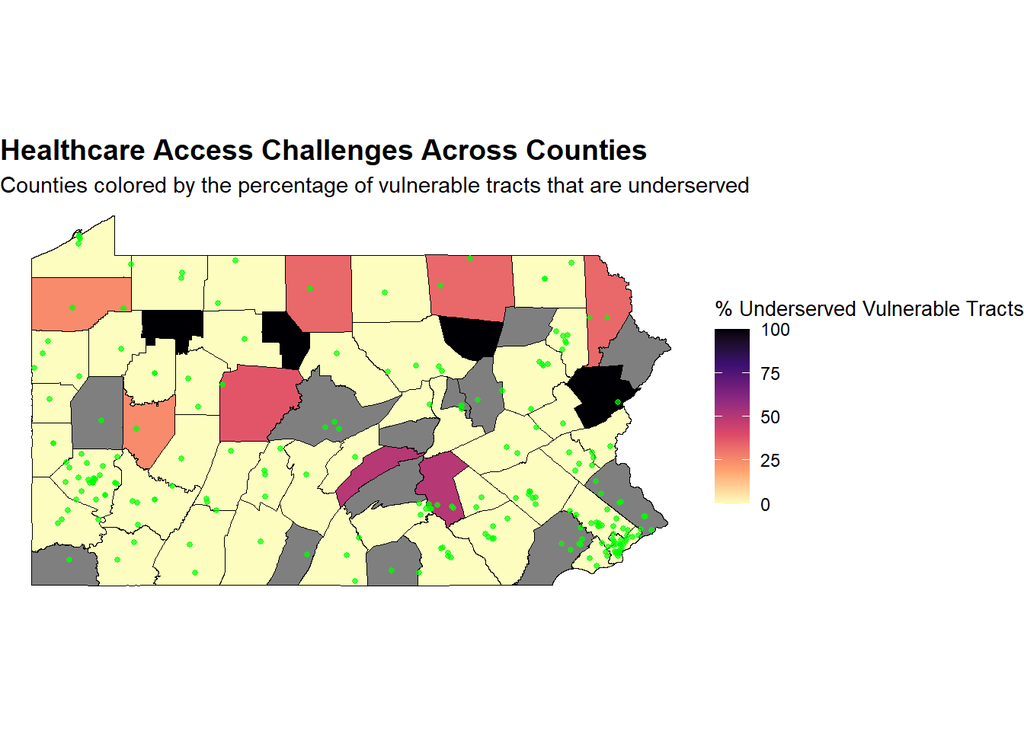

```r
# Create county-level access map
library(ggplot2)
library(viridis)

# Join back to county data
counties_proj_key <- counties_proj %>%
  mutate(
    join_name = COUNTY_NAM %>%
      str_squish() %>%
      str_to_upper() %>%
      str_replace(regex("\\s+COUNTY$", ignore_case = TRUE), "")
  )

county_stats_key <- county_stats %>%
  st_drop_geometry() %>%
  mutate(
    join_name = NAMELSADCO %>%
      str_squish() %>%
      str_to_upper() %>%
      str_replace(regex("\\s+COUNTY$", ignore_case = TRUE), "")
  )

counties_joined_new <- counties_proj_key %>%
  left_join(
    county_stats_key %>% select(join_name, everything()),
    by = "join_name"
  )

## plot
ggplot() +
  geom_sf(data = counties, color = "white") +
  geom_sf(data = counties_joined_new , aes(fill = pct_underserved), color = "black", size = 0.2) +
  geom_sf(data = hospitals, color = "green", size = 1, alpha = 0.7) +
  scale_fill_viridis_c(
    name = "% Underserved Vulnerable Tracts",
    option = "magma",
    direction = -1
  ) +
  labs(
    title = "Healthcare Access Challenges Across Counties",
    subtitle = "Counties colored by the percentage of vulnerable tracts that are underserved",
  ) +
  theme_void() +
  theme(
    legend.position = "right",
    plot.title = element_text(face = "bold", size = 14),
    plot.subtitle = element_text(size = 11),
    legend.title = element_text(size = 10),
    legend.text = element_text(size = 9)
  )
```

**Requirements:** - Fill counties by percentage of vulnerable tracts that are underserved - Include hospital locations as points - Use an appropriate color scheme - Include clear title, subtitle, and caption - Use `theme_void()` or similar clean theme - Add a legend with formatted labels

### Map 2: Detailed Vulnerability Map

Create a map highlighting underserved vulnerable tracts.

**Your Task:**

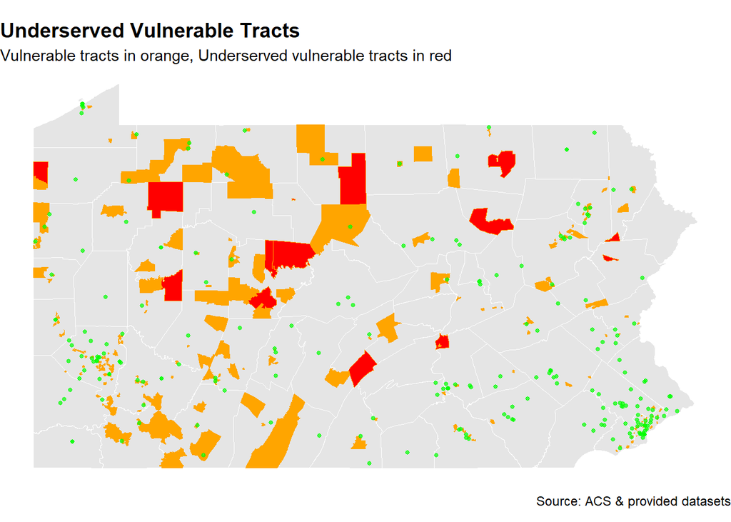

```r
# Create detailed tract-level map

ggplot() +
  geom_sf(data = counties, color = "white") +
  geom_sf(data = tracts_vul_proj, fill = "orange", color = "orange") +
  geom_sf(data = underserved, fill = "red", color = "orange") +
  geom_sf(data = hospitals, color = "green", size = 1, alpha = 0.7) +
  labs(
    title = "Underserved Vulnerable Tracts",
    subtitle = "Vulnerable tracts in orange, Underserved vulnerable tracts in red",
    caption = "Source: ACS & provided datasets"
  ) +
  theme_void() +
  theme(
    plot.title = element_text(face = "bold", size = 14),
    plot.subtitle = element_text(size = 11),
    plot.caption = element_text(size = 9),
    legend.position = "none"
  )
```

**Requirements:** - Show underserved vulnerable tracts in a contrasting color - Include county boundaries for context - Show hospital locations - Use appropriate visual hierarchy (what should stand out?) - Include informative title and subtitle

### Chart: Distribution Analysis

Create a visualization showing the distribution of distances to hospitals for vulnerable populations.

**Your Task:**

[figure not shown]

```r
# Create distribution visualization

ggplot(tracts_vul_proj, aes(x = dist_to_nearest_hosp_miles)) +
  geom_histogram(binwidth = 2, fill = "steelblue", color = "white") +
  labs(
    title = "Distribution of Distances to Hospitals for Vulnerable Populations",
    x = "Distance to Nearest Hospital (miles)",
    y = "Number of Counties"
  ) +
  theme_minimal(base_size = 12)
```

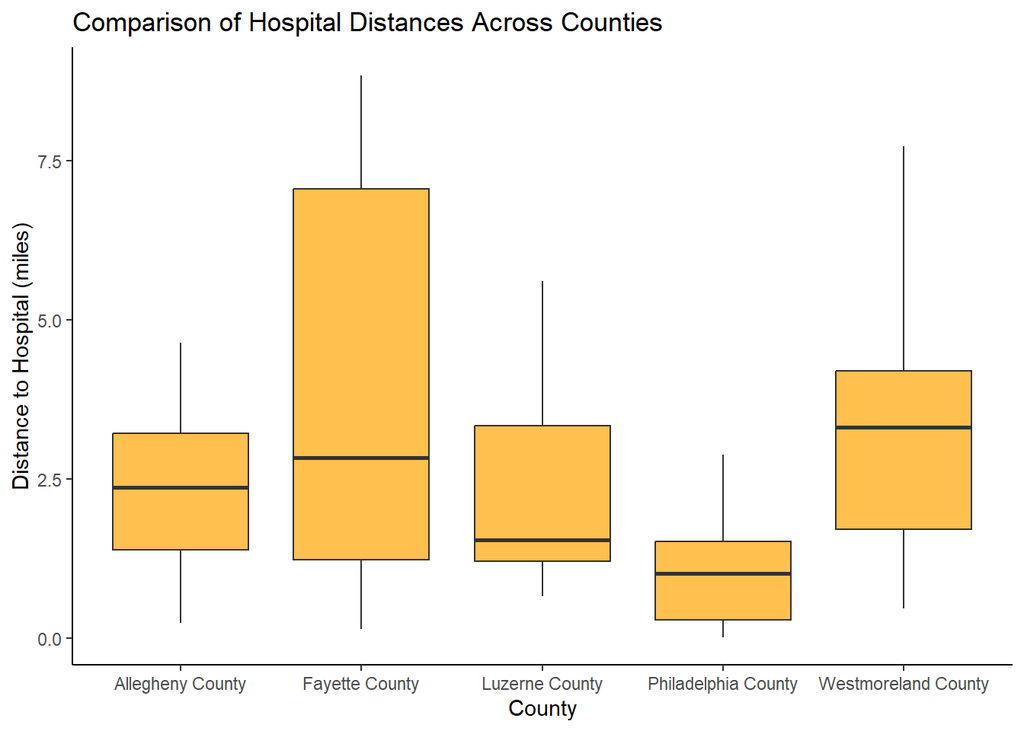

```r
top5_counties <- tracts_vul_proj %>%
  count(NAMELSADCO, sort = TRUE) %>%
  slice_head(n = 5)

subset_data <- tracts_vul_proj %>%
  filter(NAMELSADCO %in% top5_counties$NAMELSADCO)

ggplot(subset_data, aes(x = NAMELSADCO, y = dist_to_nearest_hosp_miles)) +
  geom_boxplot(fill = "orange", alpha = 0.7) +
  labs(
    title = "Comparison of Hospital Distances Across Counties",
    x = "County",
    y = "Distance to Hospital (miles)"
  ) +
  theme_classic()
```

**Suggested chart types:** - Histogram or density plot of distances - Box plot comparing distances across regions - Bar chart of underserved tracts by county - Scatter plot of distance vs. vulnerable population size

**Requirements:** - Clear axes labels with units - Appropriate title - Professional formatting - Brief interpretation (1-2 sentences as a caption or in text)

## Part 3: Bring Your Own Data Analysis

Choose your own additional spatial dataset and conduct a supplementary analysis.

### Challenge Options

Choose ONE of the following challenge exercises, or propose your own research question using OpenDataPhilly data (https://opendataphilly.org/datasets/).

**Note these are just loose suggestions to spark ideas - follow or make your own as the data permits and as your ideas evolve. This analysis should include bringing in your own dataset, ensuring the projection/CRS of your layers align and are appropriate for the analysis (not lat/long or geodetic coordinate systems). The analysis portion should include some combination of spatial and attribute operations to answer a relatively straightforward question**

#### Education & Youth Services

**Option A: Educational Desert Analysis** - **Data:** Schools, Libraries, Recreation Centers, Census tracts (child population) - **Question:** “Which neighborhoods lack adequate educational infrastructure for children?” - **Operations:** Buffer schools/libraries (0.5 mile walking distance), identify coverage gaps, overlay with child population density - **Policy relevance:** School district planning, library placement, after-school program siting

**Option B: School Safety Zones** - **Data:** Schools, Crime Incidents, Bike Network - **Question:** “Are school zones safe for walking/biking, or are they crime hotspots?” - **Operations:** Buffer schools (1000ft safety zone), spatial join with crime incidents, assess bike infrastructure coverage - **Policy relevance:** Safe Routes to School programs, crossing guard placement

#### Environmental Justice

**Option C: Green Space Equity** - **Data:** Parks, Street Trees, Census tracts (race/income demographics) - **Question:** “Do low-income and minority neighborhoods have equitable access to green space?” - **Operations:** Buffer parks (10-minute walk = 0.5 mile), calculate tree canopy or park acreage per capita, compare by demographics - **Policy relevance:** Climate resilience, environmental justice, urban forestry investment —

#### Public Safety & Justice

**Option D: Crime & Community Resources** - **Data:** Crime Incidents, Recreation Centers, Libraries, Street Lights - **Question:** “Are high-crime areas underserved by community resources?” - **Operations:** Aggregate crime counts to census tracts or neighborhoods, count community resources per area, spatial correlation analysis - **Policy relevance:** Community investment, violence prevention strategies —

#### Infrastructure & Services

**Option E: Polling Place Accessibility** - **Data:** Polling Places, SEPTA stops, Census tracts (elderly population, disability rates) - **Question:** “Are polling places accessible for elderly and disabled voters?” - **Operations:** Buffer polling places and transit stops, identify vulnerable populations, find areas lacking access - **Policy relevance:** Voting rights, election infrastructure, ADA compliance

#### Health & Wellness

**Option F: Recreation & Population Health** - **Data:** Recreation Centers, Playgrounds, Parks, Census tracts (demographics) - **Question:** “Is lack of recreation access associated with vulnerable populations?” - **Operations:** Calculate recreation facilities per capita by neighborhood, buffer facilities for walking access, overlay with demographic indicators - **Policy relevance:** Public health investment, recreation programming, obesity prevention

#### Emergency Services

**Option G: EMS Response Coverage** - **Data:** Fire Stations, EMS stations, Population density, High-rise buildings - **Question:** “Are population-dense areas adequately covered by emergency services?” - **Operations:** Create service area buffers (5-minute drive = ~2 miles), assess population coverage, identify gaps in high-density areas - **Policy relevance:** Emergency preparedness, station siting decisions

#### Arts & Culture

**Option H: Cultural Asset Distribution** - **Data:** Public Art, Museums, Historic sites/markers, Neighborhoods - **Question:** “Do all neighborhoods have equitable access to cultural amenities?” - **Operations:** Count cultural assets per neighborhood, normalize by population, compare distribution across demographic groups - **Policy relevance:** Cultural equity, tourism, quality of life, neighborhood identity

### Data Sources

**OpenDataPhilly:** https://opendataphilly.org/datasets/ - Most datasets available as GeoJSON, Shapefile, or CSV with coordinates - Always check the Metadata for a data dictionary of the fields.

**Additional Sources:** - **Pennsylvania Open Data:** https://data.pa.gov/ - **Census Bureau (via tidycensus):** Demographics, economic indicators, commute patterns - **TIGER/Line (via tigris):** Geographic boundaries

### Recommended Starting Points

**If you’re feeling confident:** Choose an advanced challenge with multiple data layers. **If you are a beginner, choose something more manageable that helps you understand the basics**

**If you have a different idea:** Propose your own question! Just make sure: - You can access the spatial data - You can perform at least 2 spatial operations

### Your Analysis

**Your Task:**

1. **Find and load additional data**
   - Document your data source
   - Check and standardize the CRS
   - Provide basic summary statistics

```r
# Load your additional dataset
PPR <- st_read ("data/PPR_Program_Sites.geojson")
st_crs(tracts)
```

```
Coordinate Reference System:
  User input: WGS 84
  wkt:
GEOGCRS["WGS 84",
    DATUM["World Geodetic System 1984",
        ELLIPSOID["WGS 84",6378137,298.257223563,
            LENGTHUNIT["metre",1]]],
    PRIMEM["Greenwich",0,
        ANGLEUNIT["degree",0.0174532925199433]],
    CS[ellipsoidal,2],
        AXIS["geodetic latitude (Lat)",north,
            ORDER[1],
            ANGLEUNIT["degree",0.0174532925199433]],
        AXIS["geodetic longitude (Lon)",east,
            ORDER[2],
            ANGLEUNIT["degree",0.0174532925199433]],
    ID["EPSG",4326]]
```

```r
PPR_proj <- st_transform(PPR, crs = 3363)
```

**Questions to answer:** - What dataset did you choose and why? Parks & Recreation Program Sites - What is the data source and date? The data source is OpenDataPhilly, and it is data from 2022 - How many features does it contain? 171 features, indicating 171 PPR facilities - What CRS is it in? Did you need to transform it? “EPSG”,4326 I need to transform it for spatial analysis

2. **Pose a research question**

Is lack of recreation access associated with vulnerable tracts’ median income?

**Examples:** - “Do vulnerable tracts have adequate public transit access to hospitals?” - “Are EMS stations appropriately located near vulnerable populations?” - “Do areas with low vehicle access have worse hospital access?”

3. **Conduct spatial analysis**

Use at least TWO spatial operations to answer your research question.

**Required operations (choose 2+):** - Buffers - Spatial joins - Spatial filtering with predicates - Distance calculations - Intersections or unions - Point-in-polygon aggregation

**Your Task:**

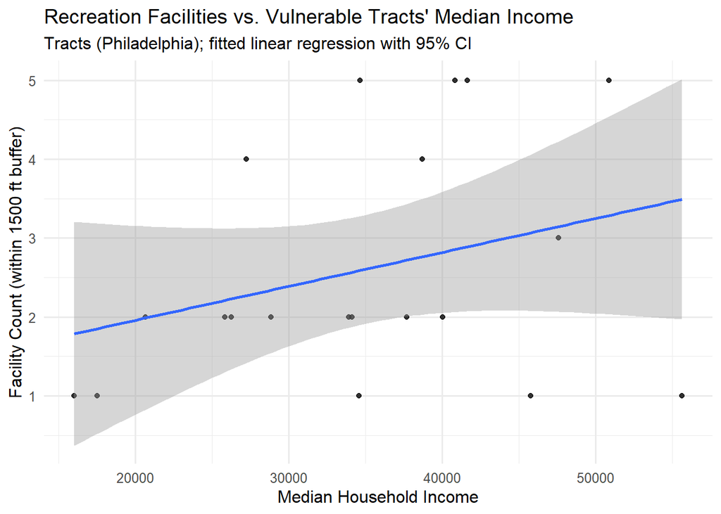

```r
library(ggplot2)
# Your spatial analysis
## Filter the vulnerable tracts in Philly
Vul_Philly <- tracts_vul_proj %>%
  filter(NAMELSADCO == "Philadelphia County")

## Buffer a walkable distance (1500 foots, 5 minutes by walk) for tracts
Vul_Philly_buf <- st_buffer(Vul_Philly, dist = 1500)

## Aggregate the number of PPR faclities in buffers
facilities_in_buf <- st_join(PPR_proj, Vul_Philly_buf, join = st_within)

facilities_count <- facilities_in_buf %>%
  st_drop_geometry() %>%
  group_by(NAMELSAD) %>%
  summarise(facility_count = n())

Vul_Philly_buf <- Vul_Philly_buf %>%
  left_join(facilities_count, by = "NAMELSAD")

## Scatter Plot and regression line
ggplot(Vul_Philly_buf, aes(x = median_incomeE, y = facility_count)) +
  geom_point(alpha = 0.8) +
  geom_smooth(method = "lm", se = TRUE) +
  labs(
    x = "Median Household Income",
    y = "Facility Count (within 1500 ft buffer)",
    title = "Recreation Facilities vs. Vulnerable Tracts' Median Income",
    subtitle = "Tracts (Philadelphia); fitted linear regression with 95% CI"
  ) +
  theme_minimal(base_size = 12)
```

**Analysis requirements:** - Clear code comments explaining each step - Appropriate CRS transformations - Summary statistics or counts - At least one map showing your findings - Brief interpretation of results (3-5 sentences)

**Your interpretation:** At the tract level, there appears to be no strong linear relationship between the number of PPR recreation facilities within a five-minute walking distance (1500 ft buffer) and the tracts’ median household income. However, it is still reasonable to believe that a lack of recreation access is associated with tract vulnerability. The main limitations of this short analysis lie in the use of median income as a metric for vulnerability and the small number of observations. If recreation facility data were available at the county level, a larger sample size and the use of vulnerable population share as a vulnerability indicator could allow for a more meaningful regression analysis and deeper insights.

## Finally - A few comments about your incorporation of feedback!

Take a few moments to clean up your markdown document and then write a line or two or three about how you may have incorporated feedback that you recieved after your first assignment.

## I have hidden my API key.

## Submission Requirements

**What to submit:**

1. **Rendered HTML document posted to your course portfolio** with all code, outputs, maps, and text
   - Use `embed-resources: true` in YAML so it’s a single file
   - All code should run without errors
   - All maps and charts should display correctly

**File naming:** `LastName_FirstName_Assignment2.html` and `LastName_FirstName_Assignment2.qmd`